# HOMEWORK 8

KIM DONGWON

2020 6 18

예제1. 어느 시장 조사기관은 여러 가지 대중매체가 주는 정보의 양을 비교하기 위해 다음과 같은 실험을 계획하였다. 40명의 성인을 랜덤하게 추출하여 철저한 면접을 통해 TV, 신문, 라디오, 잡지 중 어느 매체를 많이 접하는지에 따라 분류하였다. 다음 표는 최근에 일어난 사건들에 대한 조사 대상자들의 인지도를 측정한 실험에서 얻어진 값들을 나타내고, 값이 클수록 인지도가 높은 것을 의미한다. 이 자료를 이용하여 사람들의 인지도가 대중매체에 따라 다르다고 할 수 있는지 유의수준 5%에서 검정해보자.

```r
num<-c(16,19,25,22,21,15,16,22,21,18,13,14,15,16,15,13,19,16,20,14,11,18,18,15,14,14,10,18,15,15,11,15,11,17,17,13,14,16,13,11)

col<-factor(rep(1:4, c(10,11,9,10)))
exp<-data.frame(num,col)
fit<-lm(num~col, data = exp)
anova(fit)
```

```
## Analysis of Variance Table
##
## Response: num
##           Df Sum Sq Mean Sq F value    Pr(>F)
## col        3 185.03  61.678  8.2677 0.0002587 ***
## Residuals 36 268.56   7.460
## ---
## Signif. codes:  0 '***' 0.001 '**' 0.01 '*' 0.05 '.' 0.1 ' ' 1
```

귀무가설: 사람들의 인지도가 대중매체에 따라 다르지 않다.(모평균 동일) 대립가설: 사람들의 인지도가 대중매체에 따라 다르다.(모평균 동일하지 않다.) 분산분석 결과, 검정통계량의 값은 8.2677이고 유의확률은 0.001이하로 매우 작은 것으로 나타났다. 따라서 유의수준 5%에서 모평균이 모두 동일하다는 귀무가설을 기각할 수 있다. 즉, 사람들의 인지도가 대중매체에 따라 다르다고 할 수 있다.

예제2. 어느 회사의 마케팅 부서에서는 하나의 상품에 대해 세 가지 다른 디자인의 포장을 적용한 후 이 상품들을 서로 다른 5군데의 상점에서 한 달 동안 판매하였다. 그리고 그 판매 결과는 아래와 같다. 제품의 매출은 판매되는 상점과 제품의 포장 디자인에 따라 다르다고 할 수 있는가? 적절한 가설을 쓰고 유의수준 5%에서 이를 검정하시오.

```r
A<-factor(rep(1:5,3))
B<-factor(rep(1:3, rep(5,3)))
y<-c( 210, 230, 190, 180, 190, 195, 170, 200, 190, 193, 295, 275, 290, 275, 265)
cor2<-data.frame(A,B,y)
fit2<-lm(y~A+B, data = cor2)
anova(fit2)
```

```
## Analysis of Variance Table
##
## Response: y
##           Df  Sum Sq Mean Sq F value    Pr(>F)
## A          4   711.1   177.8  0.7033    0.6114
## B          2 24467.2 12233.6 48.3988 3.396e-05 ***
## Residuals  8  2022.1   252.8
## ---
## Signif. codes:  0 '***' 0.001 '**' 0.01 '*' 0.05 '.' 0.1 ' ' 1
```

귀무가설1: 상점에 따라 제품의 매출에는 유의한 차이가 없다. 대립가설1: 상점에 따라 제품의 매출에는 유의한 차이가 있다. 귀무가설2: 상자에 따라 제품의 매출에는 유의한 차이가 없다. 대립가설2: 상자에 따라 제품의 매출에는 유의한 차이가 있다.

분산분석표 확인 결과, 상점(A)의 효과에 대한 유의 확률은 0.6114이고 상자(B)의 효과에 대한 유의 확률은 3.396e-05다. 따라서 유의수준 5%에서 상점에 따라 제품의 매출에는 유의한 차이가 없지만 상자에 따라서는 제품의 매출에 유의한 차이가 있다.

예제3. 남녀의 성별과 고단백질로 구성된 아침 식사의 섭취 여부가 성인의 신체적 활동 능력에 영향을 미치는지를 알아보기 위하여 랜덤하게 선택된 남녀 10명에 대해 각각 5명씩 고단백질 아침식사와 저단백질 아침식사를 섭취하게 한 후, 신체적 능력을 테스트를 통해 측정하였다. 측정된 점수가 높을수록 신체 활동 능력이 더 우수하다는 것을 의미한다. 실험 결과가 아래와 같을 때, 주어진 자료에 대해 이원배치법을 적용한 후 그 결과를 해석하여라

```r
A<-factor(rep(rep(1:2,rep(5,2)),2))
B<-factor(rep(1:2,rep(10,2)))
levels(A) <- c("고단백질","저단백질")
levels(B) <- c("남성","여성")
y<-c(10, 7, 9, 6, 8, 5, 4, 7, 4, 5, 5, 4, 6, 3, 2, 3, 4, 5, 1, 2 )
pro<- data.frame(A,B,y)
fit3<- lm(y ~ A * B, data = pro)
anova(fit3)
```

```
## Analysis of Variance Table
##
## Response: y
##           Df Sum Sq Mean Sq F value    Pr(>F)
## A          1     20   20.00  8.8889 0.0088144 **
## B          1     45   45.00 20.0000 0.0003851 ***
## A:B        1      5    5.00  2.2222 0.1554875
## Residuals 16     36    2.25
## ---
## Signif. codes:  0 '***' 0.001 '**' 0.01 '*' 0.05 '.' 0.1 ' ' 1
```

#4

```r
library(MASS)
str(crabs)
```

```
## 'data.frame':    200 obs. of  8 variables:
##  $ sp   : Factor w/ 2 levels "B","O": 1 1 1 1 1 1 1 1 1 1 ...
##  $ sex  : Factor w/ 2 levels "F","M": 2 2 2 2 2 2 2 2 2 2 ...
##  $ index: int  1 2 3 4 5 6 7 8 9 10 ...
##  $ FL   : num  8.1 8.8 9.2 9.6 9.8 10.8 11.1 11.6 11.8 11.8 ...
##  $ RW   : num  6.7 7.7 7.8 7.9 8 9 9.9 9.1 9.6 10.5 ...
##  $ CL   : num  16.1 18.1 19 20.1 20.3 23 23.8 24.5 24.2 25.2 ...
##  $ CW   : num  19 20.8 22.4 23.1 23 26.5 27.1 28.4 27.8 29.3 ...
##  $ BD   : num  7 7.4 7.7 8.2 8.2 9.8 9.8 10.4 9.7 10.3 ...
```

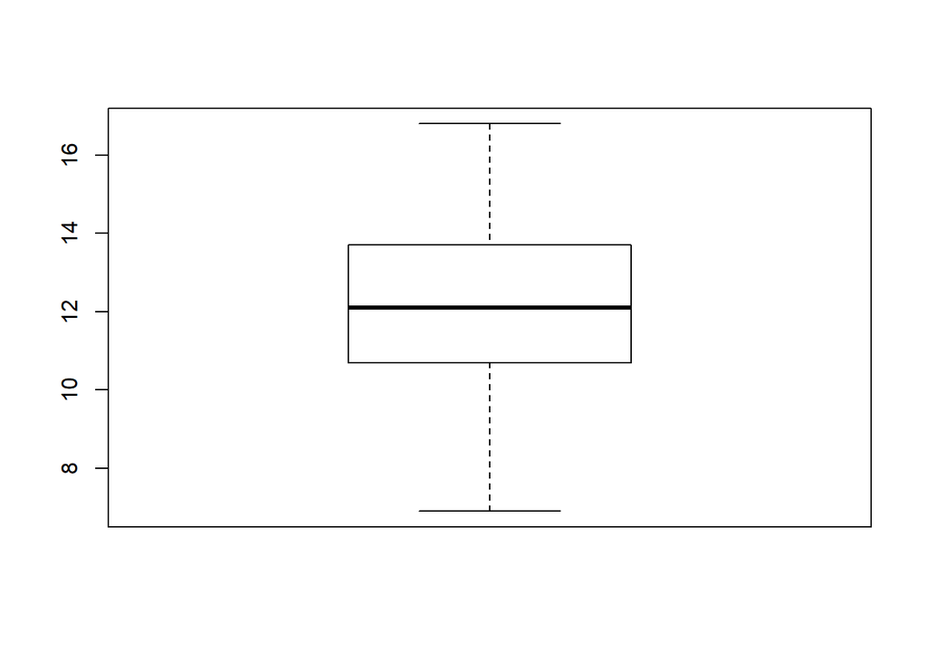

```r
A<- factor(rep(rep(1:2,rep(50,2)),2))
B<- factor(rep(1:2,rep(100,2)))
levels(A) <- c("B","O")
levels(B) <- c("M","F")
y<-crabs$RW
cra<- data.frame(A,B,y)

c1<-cra[cra$A=="B"& cra$B=="F",]
c2<-cra[cra$A=="B"& cra$B=="M",]
c3<-cra[cra$A=="O"& cra$B=="F",]
c4<-cra[cra$A=="O"& cra$B=="M",]

cr1<-c1$y ;boxplot(cr1);
```

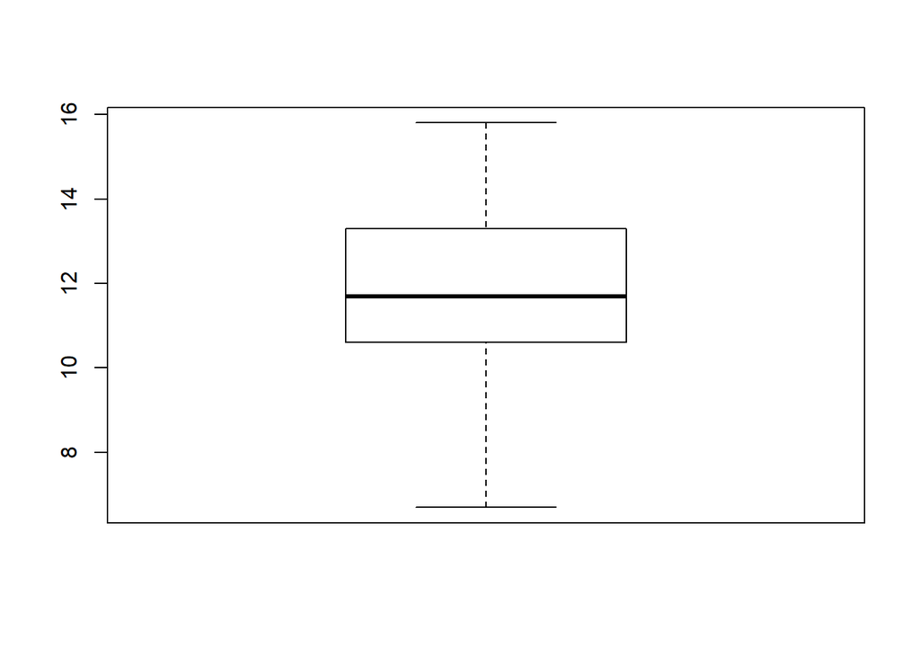

```r
cr2<-c2$y ;boxplot(cr2);
```

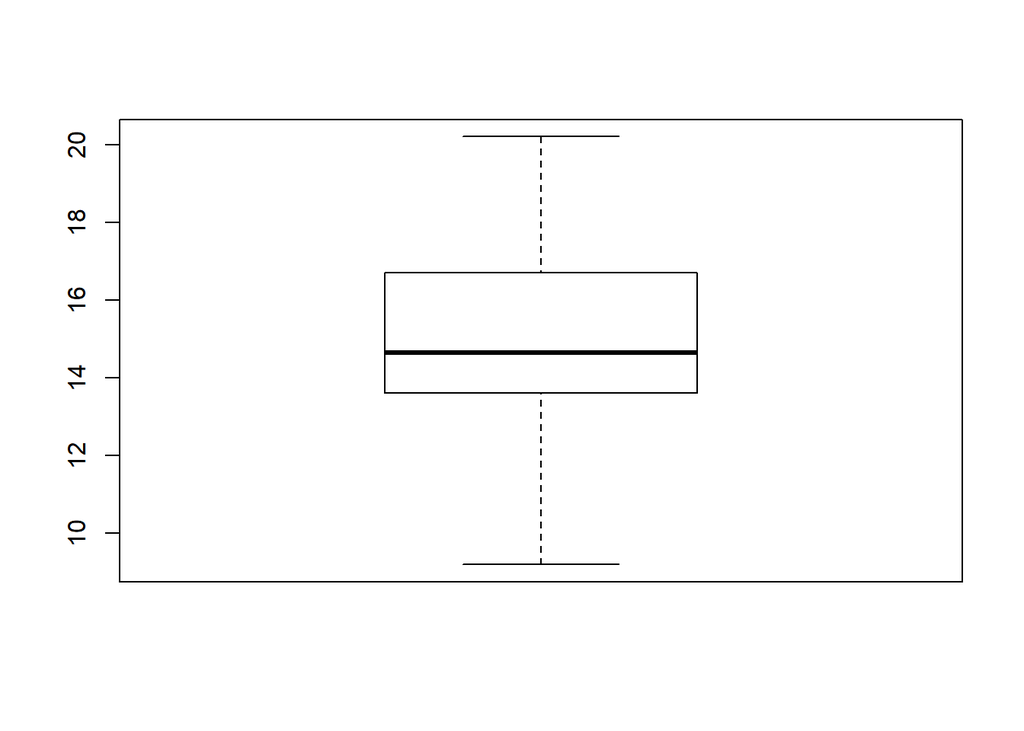

```r
cr3<-c3$y ;boxplot(cr3);
```

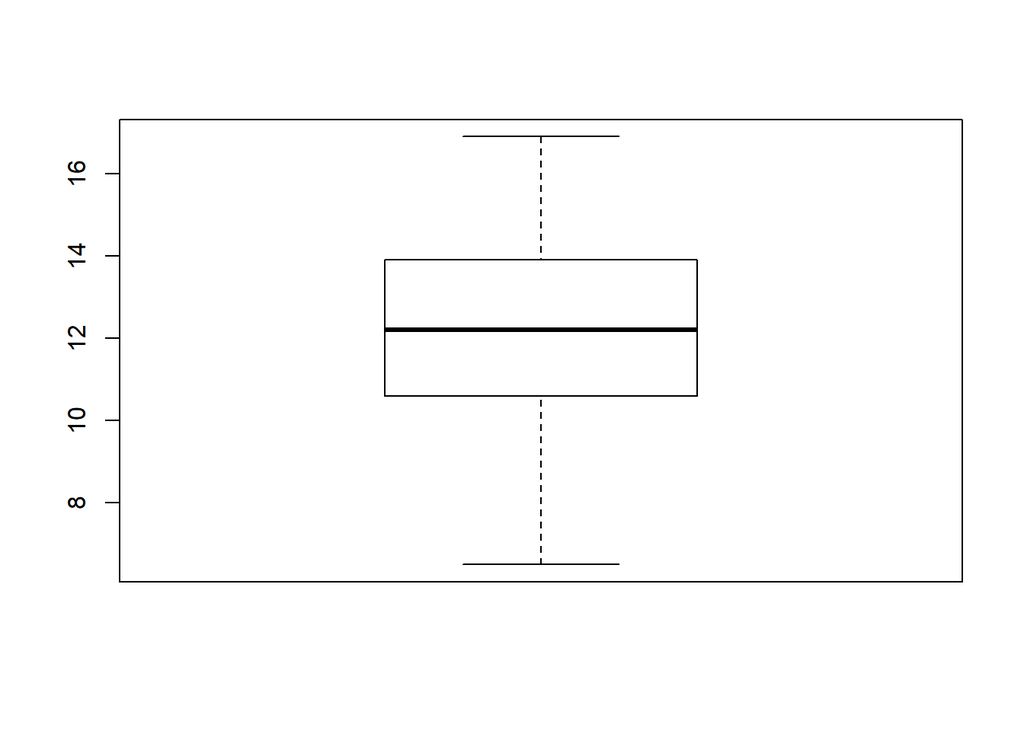

```r
cr4<-c4$y ;boxplot(cr4); #1번째 질문
```

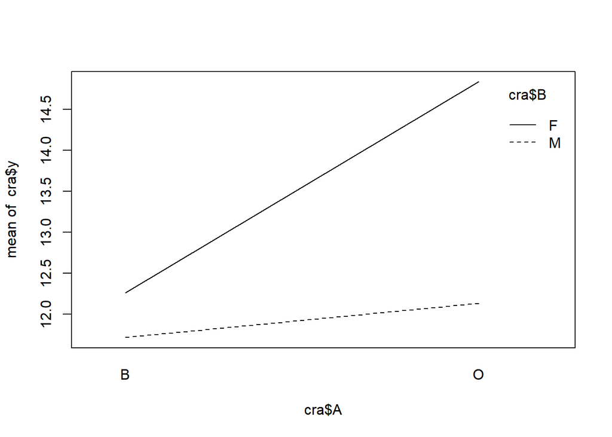

```r
interaction.plot(cra$A,cra$B,cra$y) # 2번째 질문
```

1번째 질문에 대해서는 눈으로 봤을 때 변수 sp, sex에 따라 나누어진 각 그룹에 반응변수 RW의 Boxplot그려보면 평균의 크기가 같다고 보기는 힘들다.cra$A=="O"& cra$B==“F”에서 다른 그룹보다 평균이 좀 큰 모습이 나타난다. 2번째 질문에 대해서는 두 개의 선 그래프를 그렸을 때 두 직선이 평행하지 않으므로 변수 sp, sex간의 교호작용이 존재한다.

#5

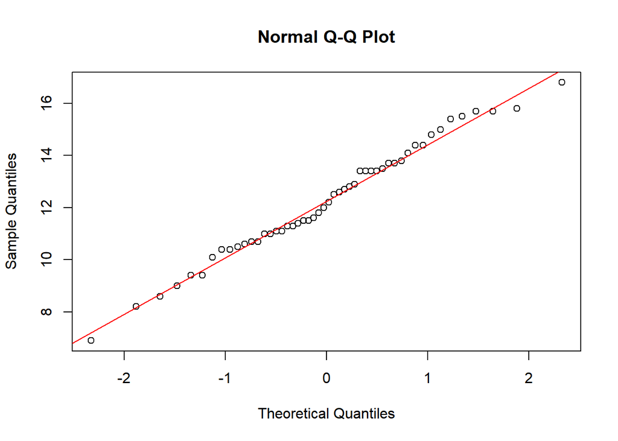

```r
qqnorm(c1$y)
qqline(c1$y, col= "red")
```

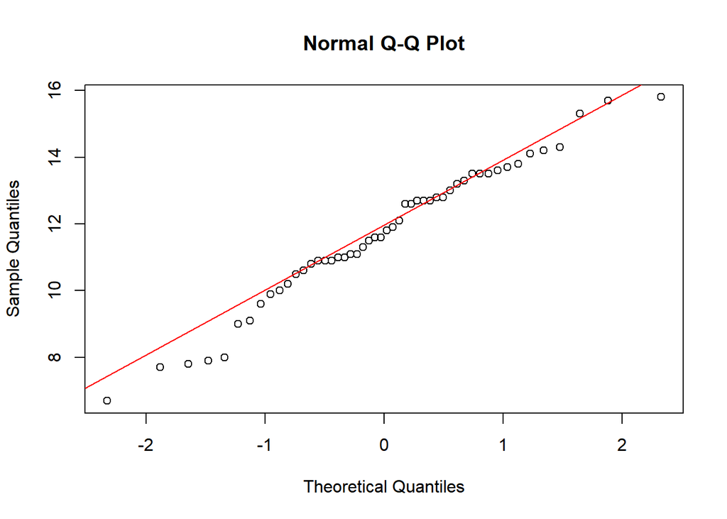

```r
qqnorm(c2$y)
qqline(c2$y, col= "red")
```

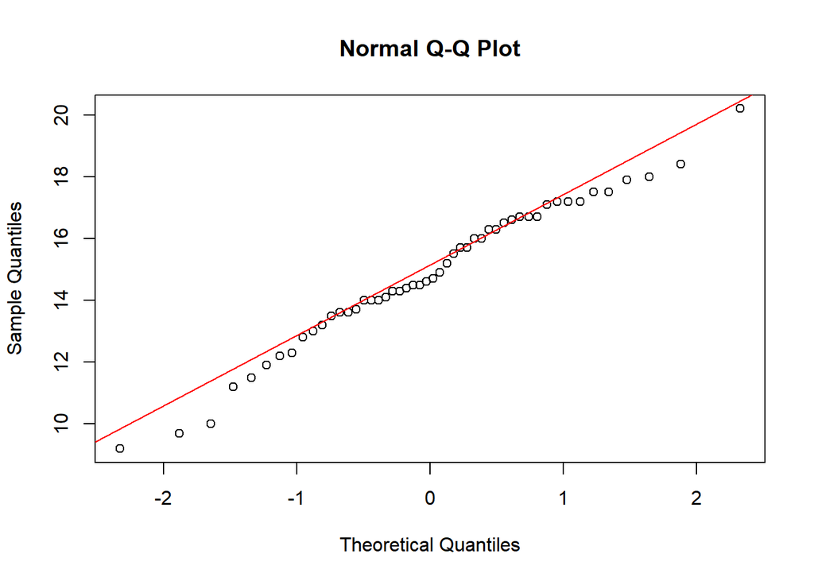

```r
qqnorm(c3$y)
qqline(c3$y, col= "red")
```

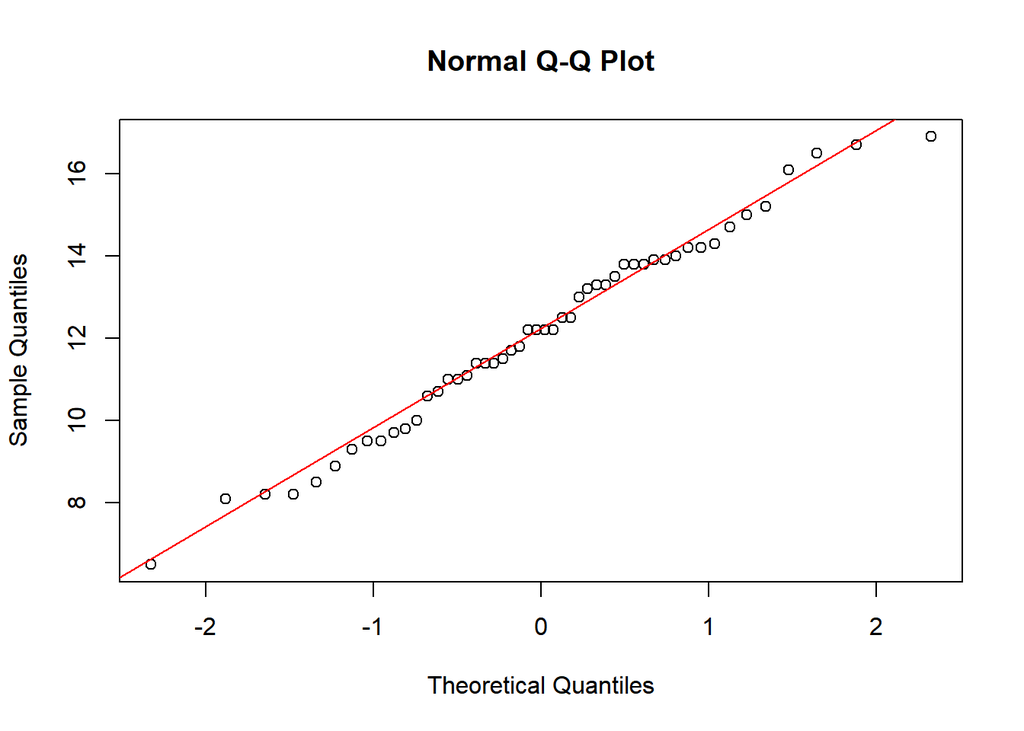

```r
qqnorm(c4$y)
qqline(c4$y, col= "red")
```

변수 sp, sex에 따라 나누어진 각 그룹에서 q-q plot을 통해 오차의 정규성을 확인해 보면, 4 그룹 모두에서 대부분 데이터들이 빨간 선 주위에 모여있음을 확인할 수 있으므로 오차의 정규성을 만족함을 알 수 있다.

#6

```r
fit6<- lm(y ~ A * B, data = cra)
anova(fit6)
```

```
## Analysis of Variance Table
##
## Response: y
##            Df  Sum Sq Mean Sq F value    Pr(>F)
## A           1  112.05 112.050  21.608 6.133e-06 ***
## B           1  131.38 131.382  25.336 1.087e-06 ***
## A:B         1   58.00  57.996  11.184 0.0009884 ***
## Residuals 196 1016.36   5.186
## ---
## Signif. codes:  0 '***' 0.001 '**' 0.01 '*' 0.05 '.' 0.1 ' ' 1
```

귀무가설: 변수 sp에 따른 RW값에 유의한 차이가 없다. 귀무가설: 변수 sex에 따른 RW값에 유의한 차이가 없다. 귀무가설: 변수 sp와 변수 sex 사이 상호작용은 없다. 분산분석 결과, 유의수준 5%에서 변수 sex(B)와 변수 sp(A)에 따른 상호작용은 존재하는 것으로 나타났다. ( p-value=0.0009884). 또한 변수 sp와 변수 sex에 따른 각각RW값의 차이는 존재한다. 각각 p-value값이 0.05보다 작아 귀무가설을 기각하기 때문이다.

#7

```r
crop<- read.csv("C:/Users/r english/Desktop/r/crop.csv")
crop$fertilizer <- factor(crop$fertilizer)
table(crop$fertilizer)
```

```
##
##  1  2  3
## 32 32 32
```

```r
fit7<-lm(yield ~ fertilizer, data = crop)
anova(fit7)
```

```
## Analysis of Variance Table
##
## Response: yield
##            Df Sum Sq Mean Sq F value    Pr(>F)
## fertilizer  2  6.068 3.03402  7.8628 0.0006999 ***
## Residuals  93 35.886 0.38587
## ---
## Signif. codes:  0 '***' 0.001 '**' 0.01 '*' 0.05 '.' 0.1 ' ' 1
```

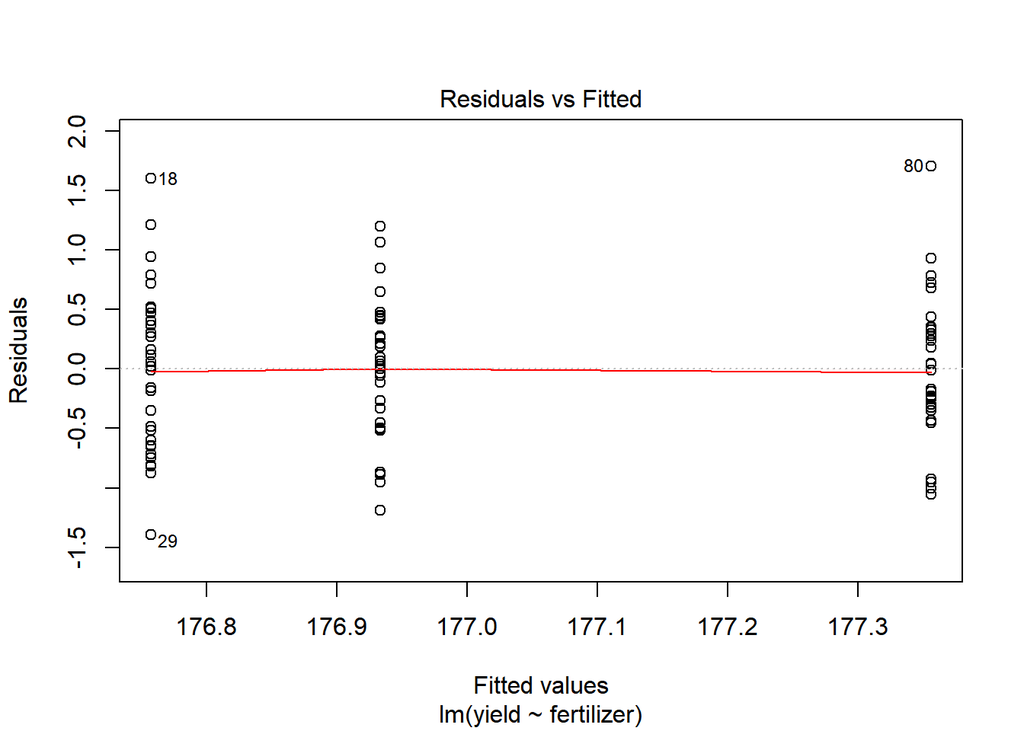

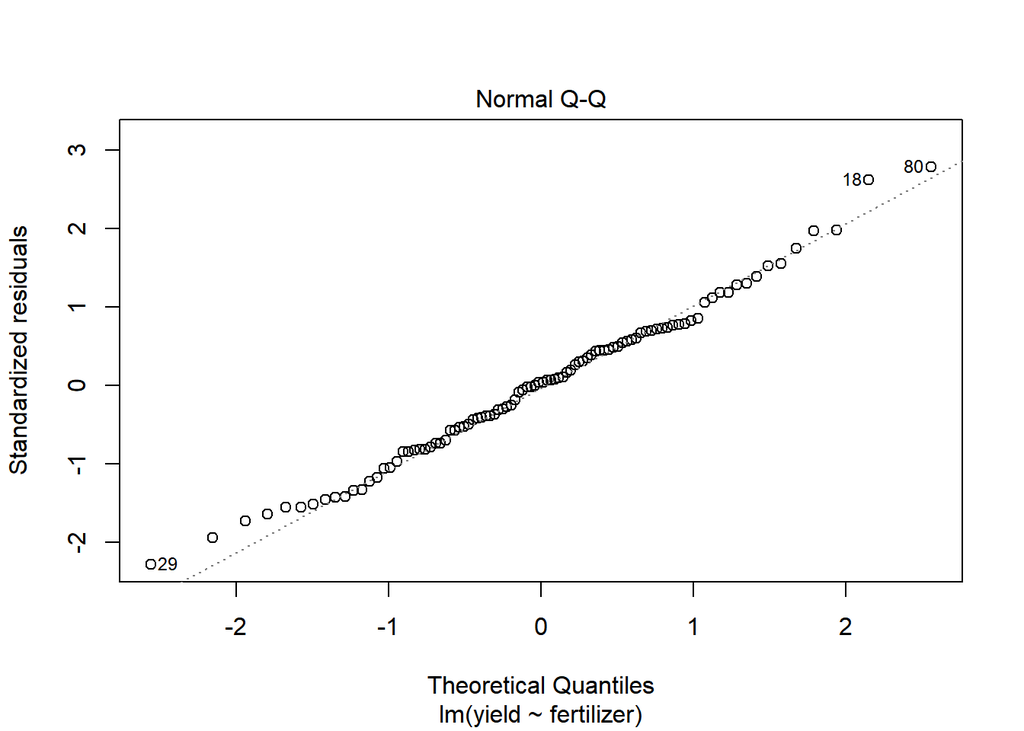

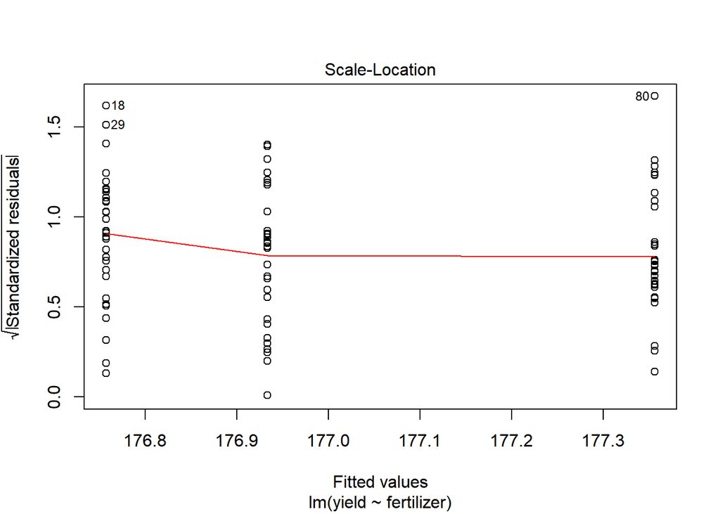

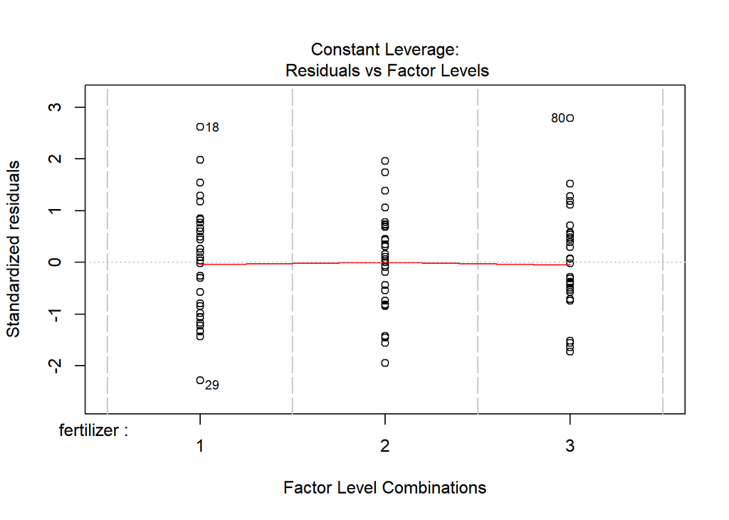

```r
plot(fit7)
```

귀무가설: yield값은 fertilizer에 따라 유의한 차이가 없다.(모평균 동일) 대립가설: yield값은 fertilizer에 따라 유의한 차이가 있다.(모평균 동일하지 않다.) 분산분석 결과, 검정통계량의 값은 7.8628이고 유의확률은 0.0006999 , 즉0.001이하인 매우 작은 값으로 나타났다. 따라서 유의수준 5%에서 fertilizer 종류에 관계없이 모평균이 모두 동일하다는 귀무가설을 기각할 수 있다. 즉, yield값은는 fertilizer에 따라 유의한 차이가 있다.

잔차도를 활용한 등분산성 가정의 경우 fertilizer값에 관계없이 오차의 산포가 일정한 모습이 나타나는 것으로 보아 등분산성 가정을 만족하는 것으로 보인다.

#8

```r
math<- read.csv("C:/Users/r english/Desktop/r/math.csv")
str(math)
```

```
## 'data.frame':    861 obs. of  4 variables:
##  $ X      : int  1 2 3 4 5 6 7 8 9 10 ...
##  $ score  : int  5 13 7 20 11 16 18 4 7 17 ...
##  $ courses: Factor w/ 3 levels "Algebra","Analysis",..: 1 1 1 1 1 1 1 1 1 1 ...
##  $ gender : Factor w/ 2 levels "F","M": 2 2 2 2 2 2 2 2 2 2 ...
```

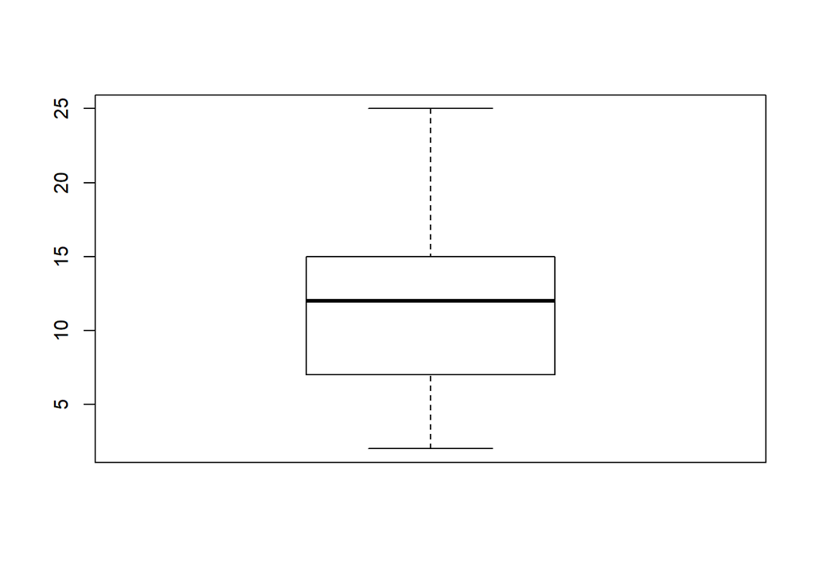

```r
A<-factor(c(rep(1:2,c(48,82)),rep(1:2,c(223,387)),rep(1:2,c(67,54))))
B<- factor(rep(1:3,c(130,610,121)))
levels(A) <- c("M","F")
levels(B) <- c("Algebra","analysis","Calculus")
y<-math$score
mat<- data.frame(A,B,y)

m1<-mat[mat$A=="M"& mat$B=="Algebra",]
m2<-mat[mat$A=="M"& mat$B=="analysis",]
m3<-mat[mat$A=="M"& mat$B=="Calculus",]
m4<-mat[mat$A=="F"& mat$B=="Algebra",]
m5<-mat[mat$A=="F"& mat$B=="analysis",]
m6<-mat[mat$A=="F"& mat$B=="Calculus",]
ma1<-m1$y ;boxplot(ma1);
```

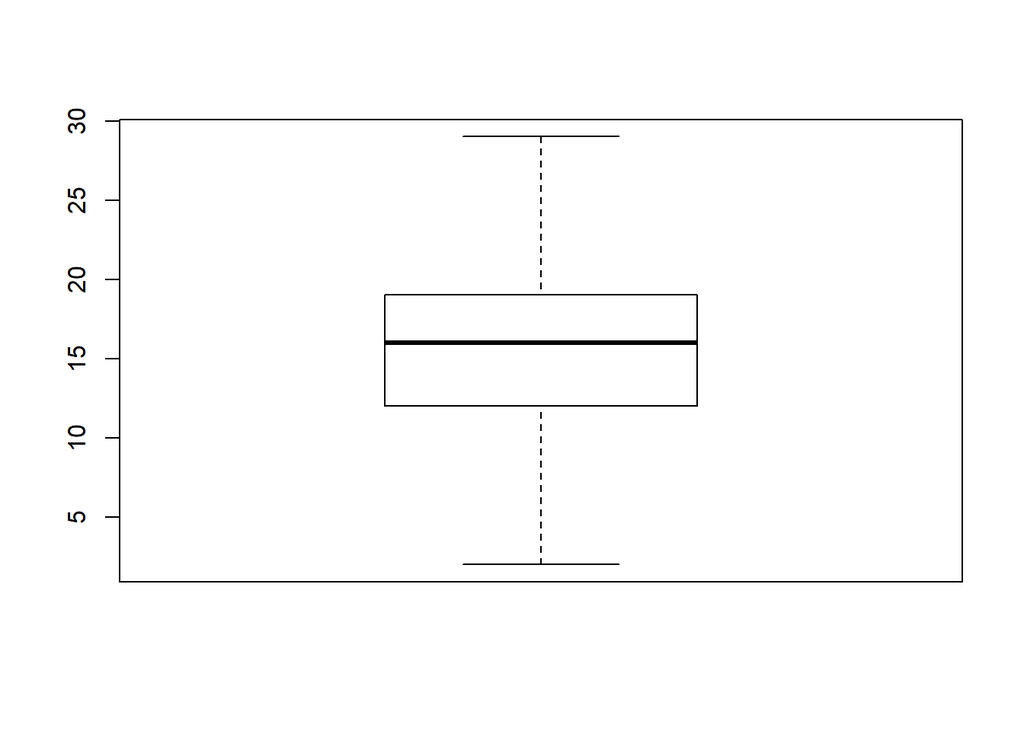

```r
ma2<-m2$y ;boxplot(ma2);
```

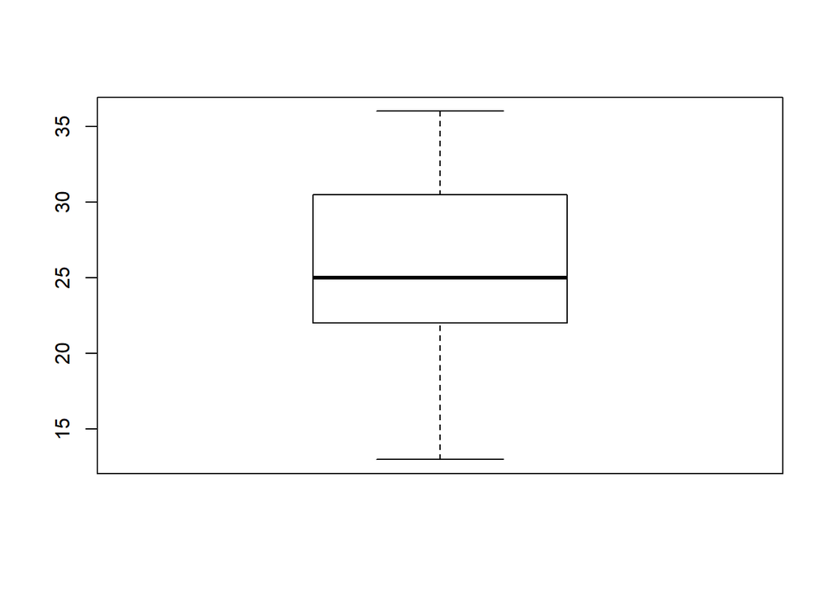

```r
ma3<-m3$y ;boxplot(ma3);
```

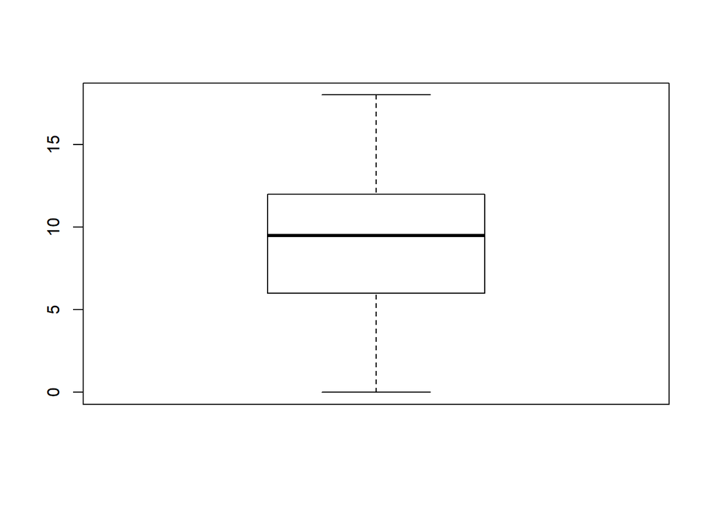

```r
ma4<-m4$y ;boxplot(ma4);
```

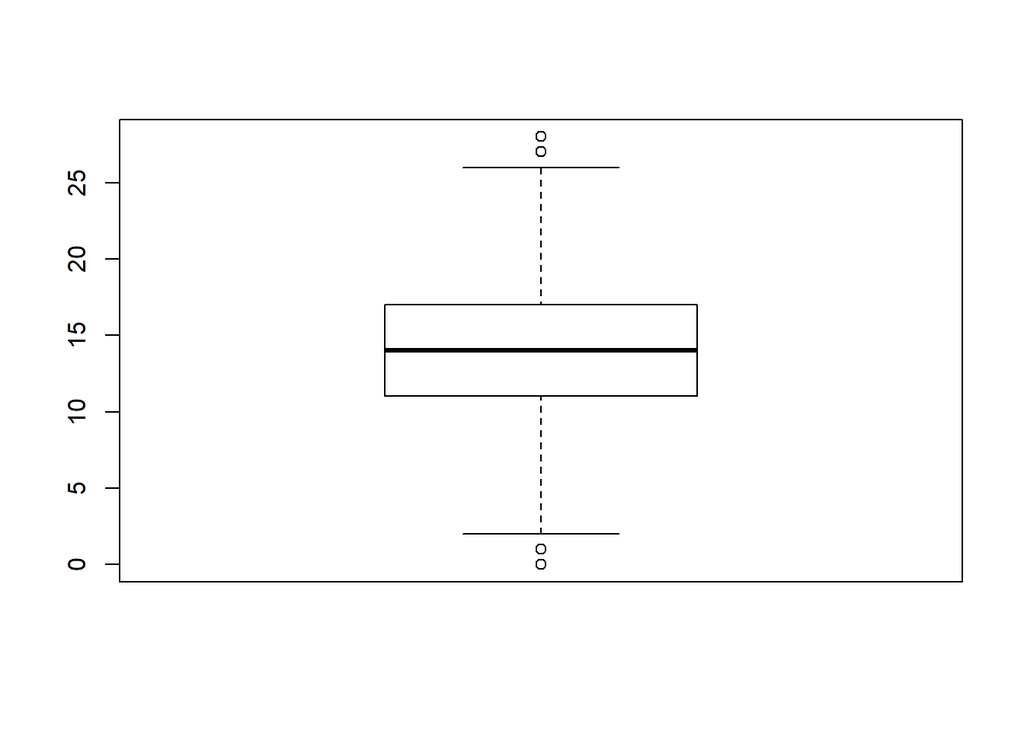

```r
ma5<-m5$y ;boxplot(ma5);
```

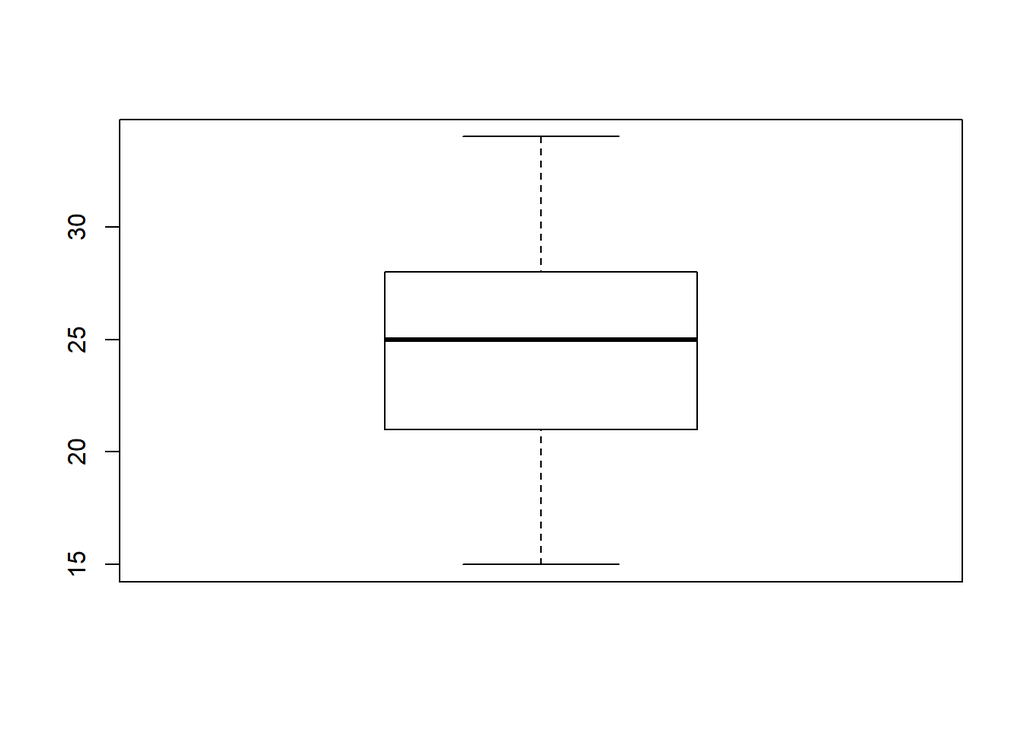

```r
ma6<-m6$y ;boxplot(ma6);
```

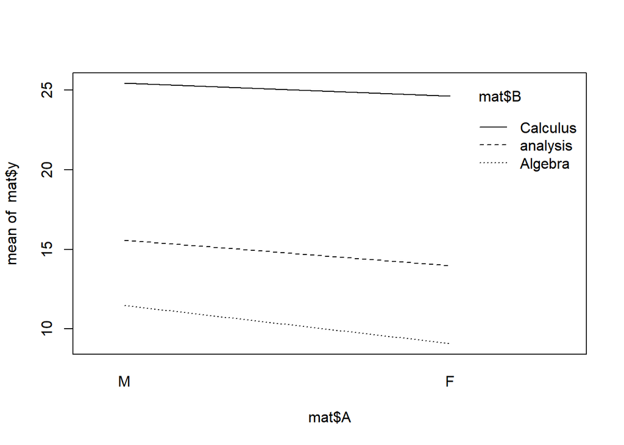

```r
#1번째 질문
interaction.plot(mat$A,mat$B,mat$y) # 2번째 질문
```

1번째 질문에 대해서는 눈으로 봤을 때 평균의 차이가 6그룹에서 다 같다고 보기엔 어려울것같다. 2번째 질문에 대해서는 세 개의 선 그래프를 그렸을 때 그래프가 거의 평행한것으로 나타나 교호작용이 거의 없을 것이라 판단했다.

#9

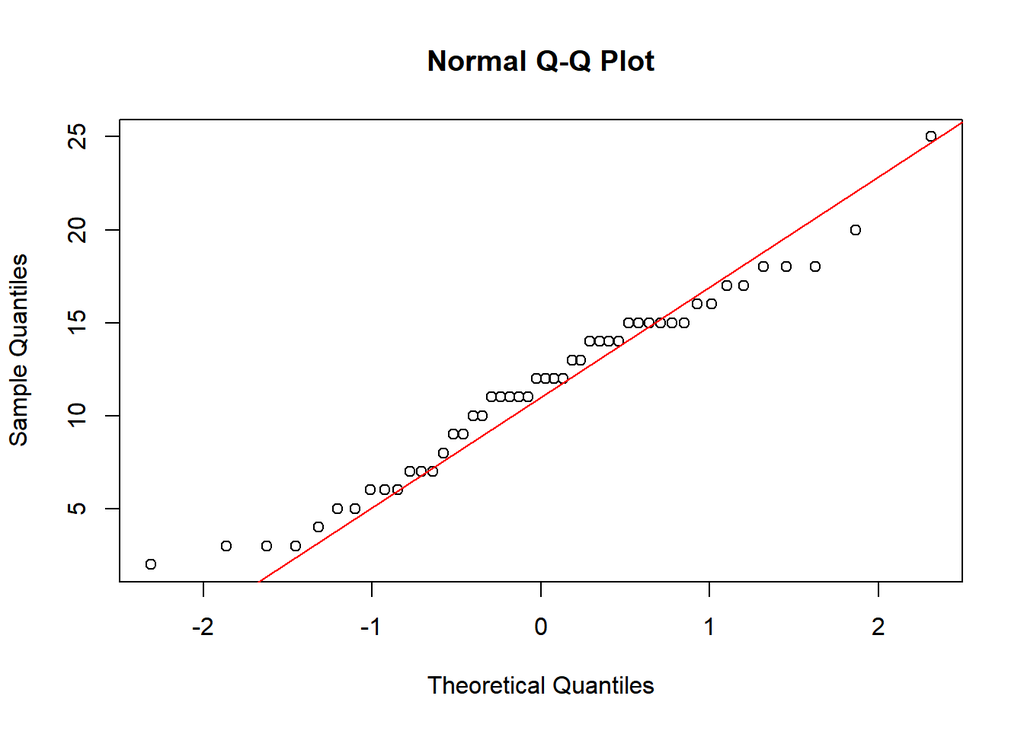

```r
qqnorm(m1$y)
qqline(m1$y, col= "red")
```

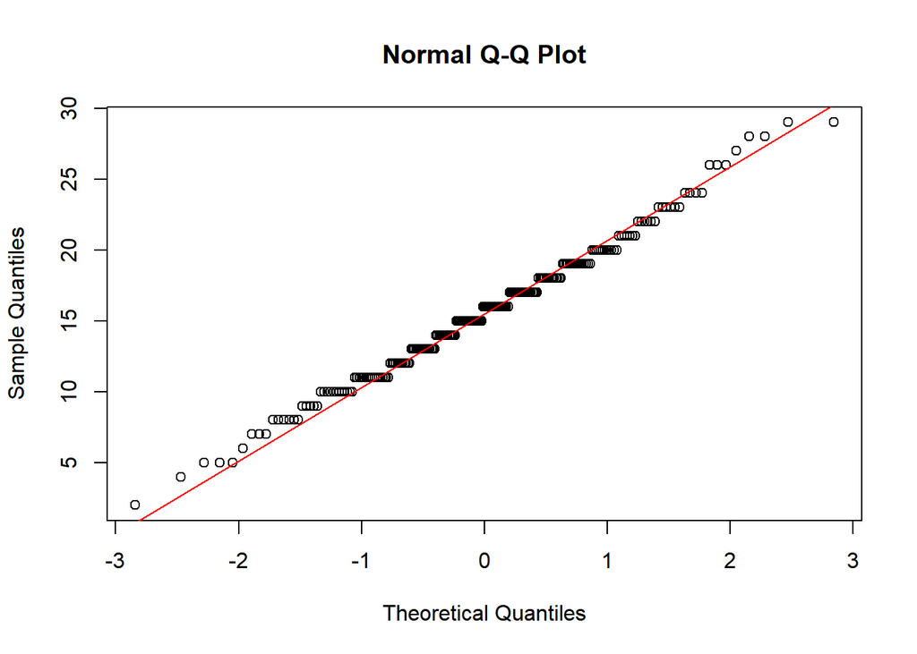

```r
qqnorm(m2$y)
qqline(m2$y, col= "red")
```

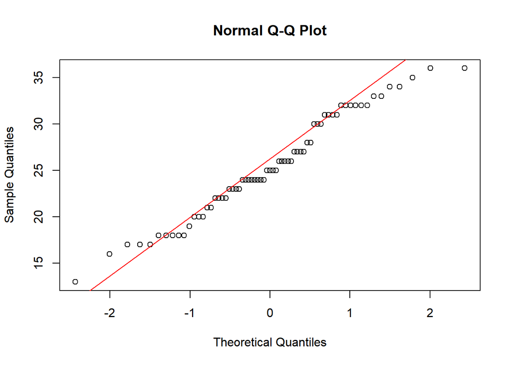

```r
qqnorm(m3$y)
qqline(m3$y, col= "red")
```

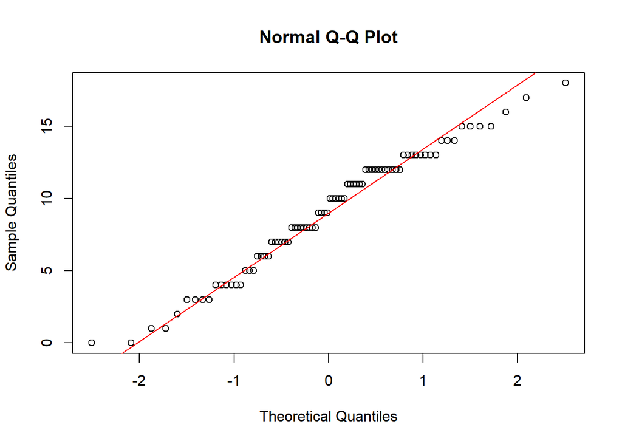

```r
qqnorm(m4$y)
qqline(m4$y, col= "red")
```

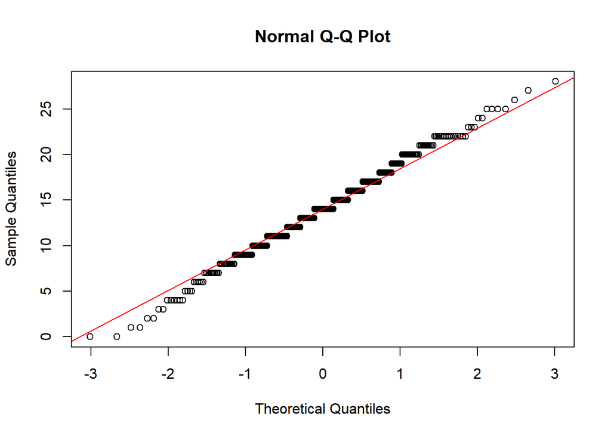

```r
qqnorm(m5$y)
qqline(m5$y, col= "red")
```

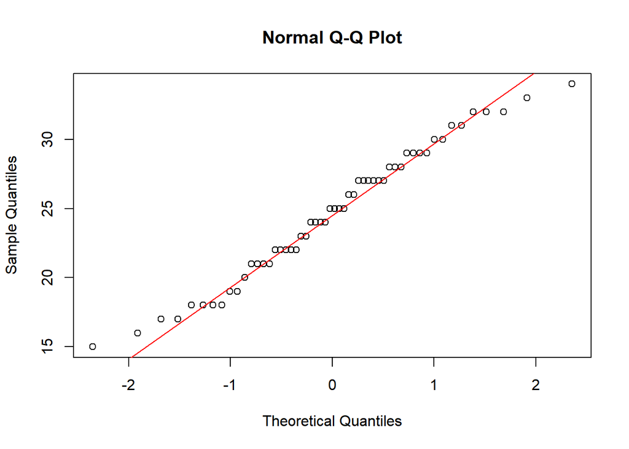

```r
qqnorm(m6$y)
qqline(m6$y, col= "red")
```

변수 gender와 course에 따라 나누어진 각 그룹에서 q-q plot을 통해 오차의 정규성을 확인해 보면, 6 그룹 모두에서 대부분 데이터들이 빨간 선 주위에 모여있음을 확인할 수 있으므로 오차의 정규성을 만족함을 알 수 있다.

#10

```r
fit10<- lm(y ~ A * B, data = mat)
anova(fit10)
```

```
## Analysis of Variance Table
##
## Response: y
##            Df  Sum Sq Mean Sq  F value    Pr(>F)
## A           1  1430.5  1430.5  58.5855 5.253e-14 ***
## B           2 14704.7  7352.3 301.1119 < 2.2e-16 ***
## A:B         2    37.6    18.8   0.7709    0.4629
## Residuals 855 20876.8    24.4
## ---
## Signif. codes:  0 '***' 0.001 '**' 0.01 '*' 0.05 '.' 0.1 ' ' 1
```

Two-way ANOVA를 사용하되, interaction plot에서 교호작용이 조금이나마 존재한다다 파악해 *로 A와 B를 연결한다.

귀무가설: 변수 gender에 따라서 score값에 유의한 차이는 없다. 귀무가설: 변수 courses에 따라서 score값에 유의한 차이는 없다. 귀무가설: 변수 gender와 변수 courses 사이 상호작용은 없다. 분산분석 결과, 유의수준 5%에서 변수 courses(B)와 변수 gender(A)에 따른 상호작용은 존재하지 않는 것으로 나타났다. ( p-value=0.4629). 또한 변수 gender와 변수 courses에 따른 각각 score값의 차이는 존재한다. 각각 p-value값이 0.05보다 작아 귀무가설을 기각하기 때문이다.